# DƏRS 5: Formativ Qiymətləndirmə Strategiyaları

Öyrənmə prosesi zamanı effektiv geribildirim metodları

Azərbaycan Respublikası Təhsil Nazirliyi - Peşəkar İnkişaf Mərkəzi

2025-08-01

# 1 Dərsin Öyrənmə Məqsədləri

Bu dərsin sonunda siz aşağıdakıları bacara biləcəksiniz:

- **Formativ qiymətləndirmə anlayışı:** Öyrənmə prosesi zamanı həyata keçirilən qiymətləndirmə metodlarını anlamaq
- **Tez geribildirim texnikaları:** Dərhal və konstruktiv əks əlaqə vermə üsullarını tətbiq etmək
- **Özünü qiymətləndirmə:** Tələbələri öz öyrənmə proseslərini izləməyə təşviq etmək
- **Həmyaşıd qiymətləndirməsi:** Tələbələr arası qarşılıqlı öyrənmə və dəstək mədəniyyəti
- **Rəqəmsal alətlər:** Texnologiya dəstəkli formativ qiymətləndirmə platformaları

# 2 Formativ Qiymətləndirmənin Əsas Prinsipləri

Formativ qiymətləndirmə öyrənmə prosesi zamanı həyata keçirilən və təlimin təkmilləşdirilməsinə yönəlmiş qiymətləndirmə növüdür.

```r
# Formativ və summativ qiymətləndirmə müqayisəsi
assessment_comparison <- tibble(
  Aspekt = c("Məqsəd", "Vaxt", "Tezlik", "Əks əlaqə", "Qiymət təsiri", "Fokusu"),
  Formativ = c("Öyrənməni yaxşılaşdırma", "Öyrənmə zamanı", "Tez-tez",
               "Dərhal və spesifik", "Minimal/yoxdur", "Proses"),
  Summativ = c("Nəticəni ölçmə", "Öyrənmə sonunda", "Nadir",
               "Gecikmiş və ümumi", "Yüksək", "Məhsul")
)

kable(assessment_comparison,
      caption = "Formativ və Summativ Qiymətləndirmə Müqayisəsi",
      col.names = c("Aspekt", "Formativ Qiymətləndirmə", "Summativ Qiymətləndirmə")) %>%
  kable_styling(bootstrap_options = c("striped", "hover", "condensed", "responsive")) %>%
  column_spec(1, bold = TRUE, color = "white", background = "#3498db") %>%
  column_spec(2, background = "#d4edda") %>%
  column_spec(3, background = "#fef5e7")
```

Formativ və Summativ Qiymətləndirmə Müqayisəsi

| Aspekt | Formativ Qiymətləndirmə | Summativ Qiymətləndirmə |
| --- | --- | --- |
| Məqsəd | Öyrənməni yaxşılaşdırma | Nəticəni ölçmə |
| Vaxt | Öyrənmə zamanı | Öyrənmə sonunda |
| Tezlik | Tez-tez | Nadir |
| Əks əlaqə | Dərhal və spesifik | Gecikmiş və ümumi |
| Qiymət təsiri | Minimal/yoxdur | Yüksək |
| Fokusu | Proses | Məhsul |

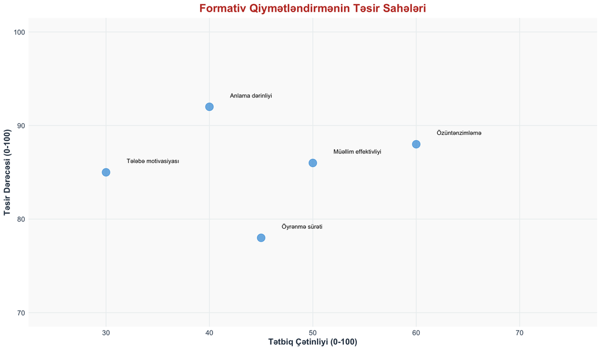

```r
# Təsir sahələri
impact_areas <- tibble(
  Sahə = c("Tələbə motivasiyası", "Öyrənmə sürəti", "Anlama dərinliyi",
           "Özüntənzimləmə", "Müəllim effektivliyi"),
  Təsir_Dərəcəsi = c(85, 78, 92, 88, 86),
  Tətbiq_Çətinliyi = c(30, 45, 40, 60, 50)
)

impact_plot <- impact_areas %>%
  ggplot(aes(x = Tətbiq_Çətinliyi, y = Təsir_Dərəcəsi)) +
  geom_point(size = 5, alpha = 0.7, color = "#3498db") +
  geom_text(aes(label = Sahə), hjust = 0, vjust = 0,
            nudge_x = 2, nudge_y = 1, size = 3) +
  scale_x_continuous(limits = c(25, 75)) +
  scale_y_continuous(limits = c(70, 100)) +
  labs(
    title = "Formativ Qiymətləndirmənin Təsir Sahələri",
    x = "Tətbiq Çətinliyi (0-100)",
    y = "Təsir Dərəcəsi (0-100)"
  ) +
  theme_formative()

print(impact_plot)
```

```r
cat("📊 FORMATİV QİYMƏTLƏNDİRMƏ TƏSİR STATİSTİKALARI:\n")
```

```
#> 📊 FORMATİV QİYMƏTLƏNDİRMƏ TƏSİR STATİSTİKALARI:
```

```r
cat("===========================================\n")
cat("🎯 Ən yüksək təsir:", impact_areas$Sahə[which.max(impact_areas$Təsir_Dərəcəsi)],
    "(", max(impact_areas$Təsir_Dərəcəsi), "%)\n")
```

```
#> 🎯 Ən yüksək təsir: Anlama dərinliyi ( 92 %)
```

```r
cat("⚡ Ən asan tətbiq:", impact_areas$Sahə[which.min(impact_areas$Tətbiq_Çətinliyi)],
    "(", min(impact_areas$Tətbiq_Çətinliyi), "% çətinlik)\n")
```

```
#> ⚡ Ən asan tətbiq: Tələbə motivasiyası ( 30 % çətinlik)
```

```r
cat("📈 Orta təsir dərəcəsi:", round(mean(impact_areas$Təsir_Dərəcəsi), 1), "%\n")
```

```
#> 📈 Orta təsir dərəcəsi: 85.8 %
```

## 2.1 Formativ Qiymətləndirmənin Dövrü

**1. Öyrənmə məqsədlərinin aydınlaşdırılması** - Tələbələrlə öyrənmə nəticələrinin paylaşılması - Uğur kriteriyalarının müəyyənləşdirilməsi

**2. Hal-hazırki vəziyyətin qiymətləndirilməsi** - Sual-cavab texnikaları - Kiçik tapşırıqlar və yoxlamalar

**3. Fərqin müəyyənləşdirilməsi** - Hal-hazırki və hədəf səviyyənin müqayisəsi - Öyrənmə boşluqlarının aşkarlanması

**4. Təlim strategiyasının uyğunlaşdırılması** - Fərdi və qrup ehtiyaclarına cavab - Öyrənmə yollarının dəyişdirilməsi

# 3 Tez Geribildirim Texnikaları

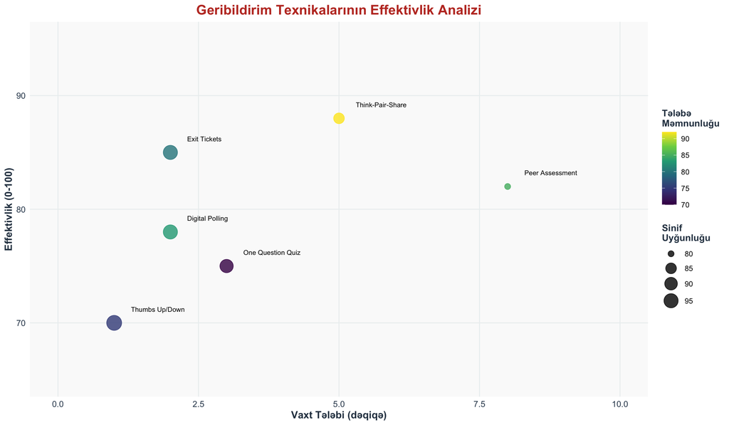

```r
# Geribildirim texnikalarının təhlili
feedback_techniques <- tibble(
  Texnika = c("Exit Tickets", "Thumbs Up/Down", "Think-Pair-Share",
              "Digital Polling", "One Question Quiz", "Peer Assessment"),
  Vaxt_Tələbi = c(2, 1, 5, 2, 3, 8),
  Effektivlik = c(85, 70, 88, 78, 75, 82),
  Tələbə_Məmnunluğu = c(80, 75, 92, 83, 70, 85),
  Sinif_Uyğunluğu = c(95, 98, 85, 95, 92, 80)
)

# Effektivlik vs Vaxt tələbi
efficiency_plot <- feedback_techniques %>%
  ggplot(aes(x = Vaxt_Tələbi, y = Effektivlik)) +
  geom_point(aes(color = Tələbə_Məmnunluğu, size = Sinif_Uyğunluğu), alpha = 0.8) +
  geom_text(aes(label = Texnika), hjust = 0, vjust = 0,
            nudge_x = 0.3, nudge_y = 1, size = 2.8) +
  scale_color_viridis_c(name = "Tələbə\nMəmnunluğu") +
  scale_size_continuous(range = c(3, 8), name = "Sinif\nUyğunluğu") +
  scale_x_continuous(limits = c(0, 10)) +
  scale_y_continuous(limits = c(65, 95)) +
  labs(
    title = "Geribildirim Texnikalarının Effektivlik Analizi",
    x = "Vaxt Tələbi (dəqiqə)",
    y = "Effektivlik (0-100)"
  ) +
  theme_formative()

print(efficiency_plot)
```

```r
# Ən effektiv texnikaların seçimi
top_techniques <- feedback_techniques %>%
  mutate(
    Balanced_Score = (Effektivlik * 0.4) + (Tələbə_Məmnunluğu * 0.3) +
                     (Sinif_Uyğunluğu * 0.2) + ((100 - Vaxt_Tələbi * 5) * 0.1)
  ) %>%
  arrange(desc(Balanced_Score)) %>%
  head(3)

kable(top_techniques %>% select(Texnika, Effektivlik, Vaxt_Tələbi, Balanced_Score),
      caption = "Ən Effektiv 3 Geribildirim Texnikası",
      col.names = c("Texnika", "Effektivlik (%)", "Vaxt (dəq)", "Ümumi Bal")) %>%
  kable_styling(bootstrap_options = c("striped", "hover", "condensed", "responsive")) %>%
  column_spec(1, bold = TRUE, color = "white", background = "#3498db") %>%
  column_spec(2:4, bold = TRUE)
```

Ən Effektiv 3 Geribildirim Texnikası

| Texnika | Effektivlik (%) | Vaxt (dəq) | Ümumi Bal |
| --- | --- | --- | --- |
| Think-Pair-Share | 88 | 5 | 87.3 |
| Exit Tickets | 85 | 2 | 86.0 |
| Digital Polling | 78 | 2 | 84.1 |

```r
cat("\n🏆 GERİBİLDİRİM TEXNİKA TÖVSİYƏLƏRİ:\n")
```

```
#>
#> 🏆 GERİBİLDİRİM TEXNİKA TÖVSİYƏLƏRİ:
```

```r
cat("===================================\n")
cat("🥇 Ən effektiv texnika:", top_techniques$Texnika[1], "\n")
```

```
#> 🥇 Ən effektiv texnika: Think-Pair-Share
```

```r
cat("⚡ Ən sürətli texnika:", feedback_techniques$Texnika[which.min(feedback_techniques$Vaxt_Tələbi)], "\n")
```

```
#> ⚡ Ən sürətli texnika: Thumbs Up/Down
```

```r
cat("❤️ Ən sevimli texnika:", feedback_techniques$Texnika[which.max(feedback_techniques$Tələbə_Məmnunluğu)], "\n")
```

```
#> ❤️ Ən sevimli texnika: Think-Pair-Share
```

## 3.1 Effektiv Geribildirim Prinsipləri

**SMART Geribildirim Formula:** - **S**pecific - Dəqiq və konkret - **M**eaningful - Mənalı və dəyərli - **A**ctionable - Əməli və tətbiq edilə bilən - **R**espectful - Hörmətli və dəstəkləyici - **T**imely - Vaxtında və uyğun

**İki Ulduz və Bir Arzu Metodu:** - ⭐ Birinci ulduz: Nəyə görə yaxşıdır - ⭐ İkinci ulduz: Başqa nə yaxşıdır - 🌟 Bir arzu: Nəyi təkmilləşdirmək olar

# 4 Özünü Qiymətləndirmə Strategiyaları

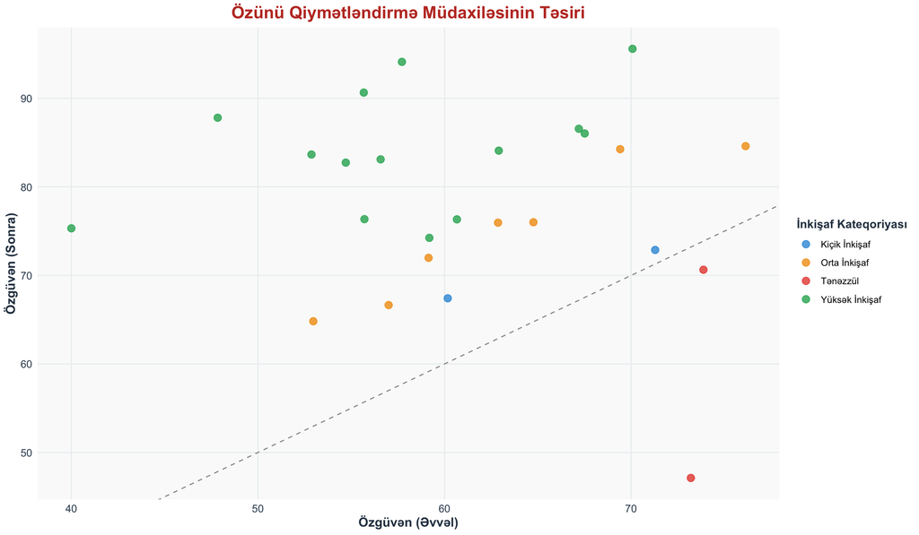

```r
# Özünü qiymətləndirmə məlumatları
set.seed(789)

self_assessment_data <- tibble(
  Tələbə_ID = 1:25,
  Özgüvən_Əvvəl = rnorm(25, 65, 12),
  Özgüvən_Sonra = rnorm(25, 78, 10),
  Metakoqnitiv_Bacarıq = rnorm(25, 72, 15),
  Akademik_Performans = rnorm(25, 75, 11)
) %>%
  mutate(
    across(Özgüvən_Əvvəl:Akademik_Performans, ~pmax(pmin(.x, 100), 40)),
    Özgüvən_Dəyişiklik = Özgüvən_Sonra - Özgüvən_Əvvəl,
    İnkişaf_Kateqoriyası = case_when(
      Özgüvən_Dəyişiklik >= 15 ~ "Yüksək İnkişaf",
      Özgüvən_Dəyişiklik >= 8 ~ "Orta İnkişaf",
      Özgüvən_Dəyişiklik >= 0 ~ "Kiçik İnkişaf",
      TRUE ~ "Tənəzzül"
    )
  )

# Özgüvən dəyişikliyinin təhlili
confidence_plot <- self_assessment_data %>%
  ggplot(aes(x = Özgüvən_Əvvəl, y = Özgüvən_Sonra, color = İnkişaf_Kateqoriyası)) +
  geom_point(size = 3, alpha = 0.8) +
  geom_abline(intercept = 0, slope = 1, linetype = "dashed", color = "gray60") +
  scale_color_manual(values = c("Yüksək İnkişaf" = "#27ae60", "Orta İnkişaf" = "#f39c12",
                               "Kiçik İnkişaf" = "#3498db", "Tənəzzül" = "#e74c3c")) +
  labs(
    title = "Özünü Qiymətləndirmə Müdaxiləsinin Təsiri",
    x = "Özgüvən (Əvvəl)",
    y = "Özgüvən (Sonra)",
    color = "İnkişaf Kateqoriyası"
  ) +
  theme_formative()

print(confidence_plot)
```

```r
# Özünü qiymətləndirmə alətləri
self_tools <- tibble(
  Alət = c("Öyrənmə Jurnalları", "KWL Cədvəlləri", "Səhv Təhlili",
           "Özünütənzimləmə Rubrikləri", "Refleksiya Tapşırıqları"),
  Yaş_Qrupu = c("7+", "6+", "11+", "12+", "9+"),
  Effektivlik = c(88, 82, 85, 95, 92),
  Tətbiq_Asanlığı = c(70, 88, 60, 75, 85)
)

kable(self_tools,
      caption = "Özünü Qiymətləndirmə Alətləri",
      col.names = c("Alət", "Yaş Qrupu", "Effektivlik (%)", "Tətbiq Asanlığı (%)")) %>%
  kable_styling(bootstrap_options = c("striped", "hover", "condensed", "responsive")) %>%
  column_spec(1, bold = TRUE, color = "white", background = "#3498db")
```

Özünü Qiymətləndirmə Alətləri

| Alət | Yaş Qrupu | Effektivlik (%) | Tətbiq Asanlığı (%) |
| --- | --- | --- | --- |
| Öyrənmə Jurnalları | 7+ | 88 | 70 |
| KWL Cədvəlləri | 6+ | 82 | 88 |
| Səhv Təhlili | 11+ | 85 | 60 |
| Özünütənzimləmə Rubrikləri | 12+ | 95 | 75 |
| Refleksiya Tapşırıqları | 9+ | 92 | 85 |

```r
cat("\n🧠 METAKOQNİTİV İNKİŞAF TƏHLİLİ:\n")
```

```
#>
#> 🧠 METAKOQNİTİV İNKİŞAF TƏHLİLİ:
```

```r
cat("===============================\n")
cat("📈 Orta özgüvən artımı:", round(mean(self_assessment_data$Özgüvən_Dəyişiklik), 1), "bal\n")
```

```
#> 📈 Orta özgüvən artımı: 17.2 bal
```

```r
cat("🎯 Yüksək inkişaf göstərənlər:", sum(self_assessment_data$İnkişaf_Kateqoriyası == "Yüksək İnkişaf"), "tələbə\n")
```

```
#> 🎯 Yüksək inkişaf göstərənlər: 14 tələbə
```

## 4.1 Özünü Qiymətləndirmə Strategiyaları

**Öyrənmə Jurnalları:** - Gündəlik öyrənmə refleksiyaları - Çətinlik və uğurların qeyd edilməsi

**KWL Cədvəlləri (Bilirəm-İstəyirəm-Öyrəndim):** - Əvvəlcədən mövcud bilgilərin aktivləşdirilməsi - Yeni biliklərin möhkəmləndirilməsi

**Səhv Təhlili:** - Səhvləri öyrənmə imkanına çevirmə - Düzəliş strategiyalarının hazırlanması

# 5 Həmyaşıd Qiymətləndirməsi

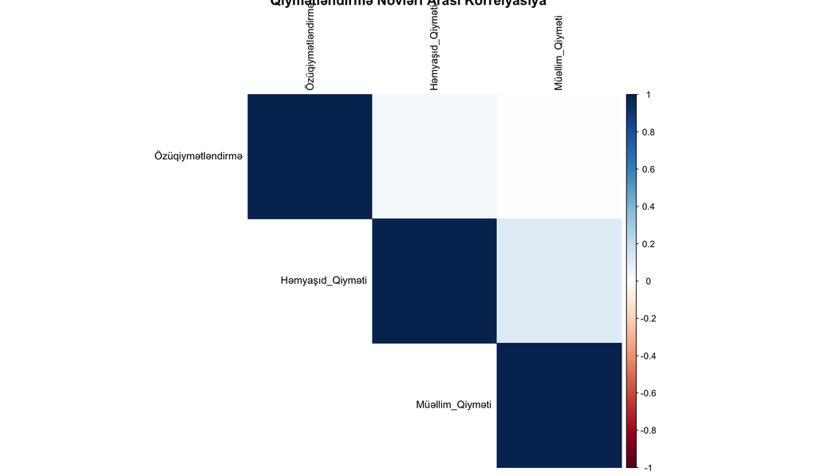

```r
# Həmyaşıd qiymətləndirmə simulyasiyası
set.seed(456)

peer_data <- tibble(
  Qrup_ID = rep(1:6, each = 15),
  Özüqiymətləndirmə = rnorm(90, 75, 8),
  Həmyaşıd_Qiyməti = rnorm(90, 73, 10),
  Müəllim_Qiyməti = rnorm(90, 74, 7),
  Qrup_Ölçüsü = rep(c(4, 5, 6, 4, 5, 6), each = 15)
) %>%
  mutate(
    across(Özüqiymətləndirmə:Müəllim_Qiyməti, ~pmax(pmin(.x, 100), 50)),
    Həmyaşıd_Müəllim_Fərq = abs(Həmyaşıd_Qiyməti - Müəllim_Qiyməti)
  )

# Qiymətləndirmə növləri arası korrelyasiya
peer_correlation <- peer_data %>%
  select(Özüqiymətləndirmə, Həmyaşıd_Qiyməti, Müəllim_Qiyməti) %>%
  cor()

corrplot(peer_correlation, method = "color", type = "upper",
         order = "hclust", tl.cex = 0.9, tl.col = "black",
         title = "Qiymətləndirmə Növləri Arası Korrelyasiya")
```

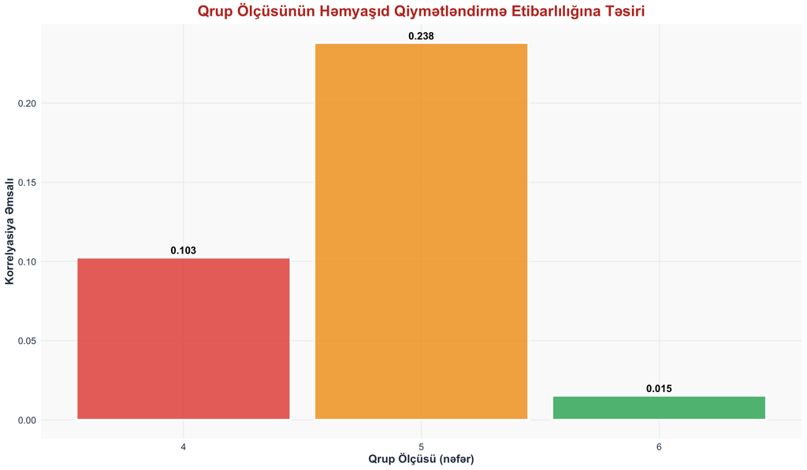

```r
# Qrup ölçüsünün təsiri
group_effect <- peer_data %>%
  group_by(Qrup_Ölçüsü) %>%
  summarise(
    Korrelyasiya = cor(Həmyaşıd_Qiyməti, Müəllim_Qiyməti),
    Orta_Fərq = mean(Həmyaşıd_Müəllim_Fərq),
    .groups = 'drop'
  )

group_plot <- group_effect %>%
  ggplot(aes(x = factor(Qrup_Ölçüsü), y = Korrelyasiya, fill = factor(Qrup_Ölçüsü))) +
  geom_col(alpha = 0.8, color = "white", size = 1) +
  geom_text(aes(label = round(Korrelyasiya, 3)), vjust = -0.5, fontface = "bold") +
  scale_fill_manual(values = c("4" = "#e74c3c", "5" = "#f39c12", "6" = "#27ae60")) +
  labs(
    title = "Qrup Ölçüsünün Həmyaşıd Qiymətləndirmə Etibarlılığına Təsiri",
    x = "Qrup Ölçüsü (nəfər)",
    y = "Korrelyasiya Əmsalı"
  ) +
  theme_formative() +
  theme(legend.position = "none")

print(group_plot)
```

```r
cat("\n🤝 HƏMYAŞID QİYMƏTLƏNDİRMƏ TƏHLİLİ:\n")
```

```
#>
#> 🤝 HƏMYAŞID QİYMƏTLƏNDİRMƏ TƏHLİLİ:
```

```r
cat("==================================\n")
cat("🎯 Optimal qrup ölçüsü:", group_effect$Qrup_Ölçüsü[which.max(group_effect$Korrelyasiya)], "nəfər\n")
```

```
#> 🎯 Optimal qrup ölçüsü: 5 nəfər
```

```r
cat("📊 Həmyaşıd-müəllim korrelyasiyası:", round(peer_correlation[2,3], 3), "\n")
```

```
#> 📊 Həmyaşıd-müəllim korrelyasiyası: 0.112
```

## 5.1 Həmyaşıd Qiymətləndirmə Strategiyaları

**Qrup Layihələri:** Kollaborativ iş və qarşılıqlı dəstək

**Həmyaşıd Redaktə:** Yazıların bir-birini yoxlaması və təkmilləşdirilməsi

**Qarşılıqlı Təlim:** Tələbələrin bir-birinə dərs deməsi

# 6 Rəqəmsal Formativ Qiymətləndirmə Alətləri

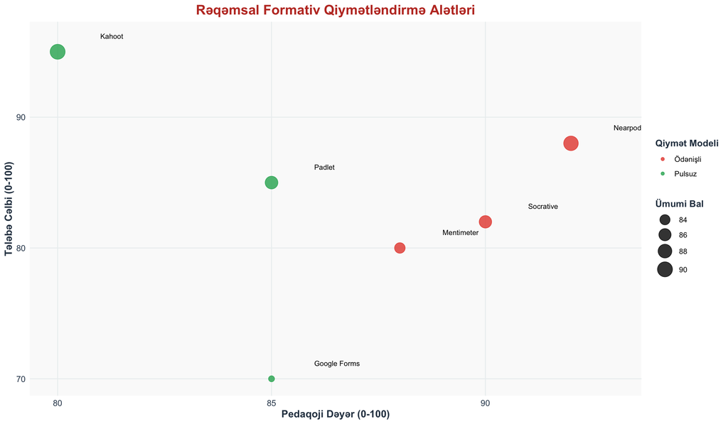

```r
# Rəqəmsal alətlərin təhlili
digital_tools <- tibble(
  Alət = c("Kahoot", "Mentimeter", "Padlet", "Google Forms", "Nearpod", "Socrative"),
  İstifadə_Asanlığı = c(95, 85, 90, 92, 88, 87),
  Tələbə_Cəlbi = c(95, 80, 85, 70, 88, 82),
  Pedaqoji_Dəyər = c(80, 88, 85, 85, 92, 90),
  Qiymət = c("Pulsuz", "Freemium", "Pulsuz", "Pulsuz", "Freemium", "Freemium")
)

# Alətlərin müqayisəsi
tools_plot <- digital_tools %>%
  mutate(
    Ümumi_Bal = (İstifadə_Asanlığı + Tələbə_Cəlbi + Pedaqoji_Dəyər) / 3,
    Pulsuz_mu = ifelse(Qiymət == "Pulsuz", "Pulsuz", "Ödənişli")
  ) %>%
  ggplot(aes(x = Pedaqoji_Dəyər, y = Tələbə_Cəlbi)) +
  geom_point(aes(color = Pulsuz_mu, size = Ümumi_Bal), alpha = 0.8) +
  geom_text(aes(label = Alət), hjust = 0, vjust = 0,
            nudge_x = 1, nudge_y = 1, size = 3) +
  scale_color_manual(values = c("Pulsuz" = "#27ae60", "Ödənişli" = "#e74c3c")) +
  scale_size_continuous(range = c(3, 8)) +
  labs(
    title = "Rəqəmsal Formativ Qiymətləndirmə Alətləri",
    x = "Pedaqoji Dəyər (0-100)",
    y = "Tələbə Cəlbi (0-100)",
    color = "Qiymət Modeli",
    size = "Ümumi Bal"
  ) +
  theme_formative()

print(tools_plot)
```

```r
# Ən yaxşı alətlər
top_tools <- digital_tools %>%
  mutate(
    Ümumi_Bal = (İstifadə_Asanlığı + Tələbə_Cəlbi + Pedaqoji_Dəyər) / 3,
    Pulsuz_Bonus = ifelse(Qiymət == "Pulsuz", 5, 0),
    Final_Bal = Ümumi_Bal + Pulsuz_Bonus
  ) %>%
  arrange(desc(Final_Bal)) %>%
  head(3)

kable(top_tools %>% select(Alət, Ümumi_Bal, Qiymət),
      caption = "Ən Yaxşı 3 Rəqəmsal Alət",
      col.names = c("Alət", "Ümumi Bal", "Qiymət")) %>%
  kable_styling(bootstrap_options = c("striped", "hover", "condensed", "responsive")) %>%
  column_spec(1, bold = TRUE, color = "white", background = "#3498db")
```

Ən Yaxşı 3 Rəqəmsal Alət

| Alət | Ümumi Bal | Qiymət |
| --- | --- | --- |
| Kahoot | 90.00000 | Pulsuz |
| Padlet | 86.66667 | Pulsuz |
| Nearpod | 89.33333 | Freemium |

```r
cat("\n💻 REQƏMSAl ALƏT TÖVSİYƏLƏRİ:\n")
```

```
#>
#> 💻 REQƏMSAl ALƏT TÖVSİYƏLƏRİ:
```

```r
cat("=============================\n")
cat("🏆 Ən yaxşı:", top_tools$Alət[1], "\n")
```

```
#> 🏆 Ən yaxşı: Kahoot
```

```r
cat("💰 Ən yaxşı pulsuz:",
    digital_tools$Alət[digital_tools$Qiymət == "Pulsuz"][1], "\n")
```

```
#> 💰 Ən yaxşı pulsuz: Kahoot
```

```r
cat("🎯 Ən yüksək pedaqoji dəyər:",
    digital_tools$Alət[which.max(digital_tools$Pedaqoji_Dəyər)], "\n")
```

```
#> 🎯 Ən yüksək pedaqoji dəyər: Nearpod
```

## 6.1 Populyar Rəqəmsal Alətlər

**Kahoot:** Oyun əsaslı sorğular və yoxlamalar

**Mentimeter:** Canlı sorğular və sual-cavab sessiyaları

**Padlet:** Kollaborativ ideya paylaşımı divarı

**Google Forms:** Sadə sorğu və qiymətləndirmə formları

**Nearpod:** İnteraktiv dərs təqdimatları

# 7 Praktik Tapşırıq

## 7.1 Final Layihəsi: Formativ Qiymətləndirmə Sistemi

**Tapşırıq 1: Geribildirim Strategiya Planı** 1. Fənniniz üçün 5 formativ texnika seçin 2. Həftəlik tətbiq cədvəli hazırlayın 3. R-də effektivlik təhlili aparın

**Tapşırıq 2: Özünü Qiymətləndirmə Alətləri** 1. Yaş qrupunuza uyğun özünü qiymətləndirmə rubrikləri 2. Metakoqnitiv bacarıq inkişaf planı 3. Pilot test və nəticə analizi

**Tapşırıq 3: Rəqəmsal İnteqrasiya** 1. Ən uyğun 3 rəqəmsal alət seçimi 2. İstifadə ssenariləri və protokolları 3. Məlumat toplama və analiz sistemi

**Təslim Formatı:** R Markdown hesabatı + Praktik Materiallar

**Təslim Müddəti:** 1 həftə

# 8 Dərsin Xülasəsi

Bu dərsdə əldə etdiyiniz əsas bacarıqlar:

✅ **Formativ qiymətləndirmə fəlsəfəsi:** Öyrənməni dəstəkləyən qiymətləndirmə yanaşımı

✅ **Tez geribildirim texnikaları:** Effektiv və konstruktiv əks əlaqə metodları

✅ **Metakoqnitiv inkişaf:** Tələbələri özünü idarə etməyə təşviq etmə

✅ **Həmyaşıd qiymətləndirməsi:** Kollaborativ öyrənmə və sosial bacarıqlar

✅ **Rəqəmsal inteqrasiya:** Texnologiya dəstəkli formativ qiymətləndirmə

## 8.1 Formativ Qiymətləndirmənin Gələcəyi

**Gələcək Trendlər:**

- **Süni İntellekt İnteqrasiyası:** AI əsaslı real vaxt təhlil və tövsiyələr
- **Mikroöyrənmə:** Kiçik, tez-tez qiymətləndirmələr
- **Oyunlaşdırma:** Qiymətləndirməni əyləncəli və motivasiyaedici etmə
- **Mobil Texnologiyalar:** Smartfon və planşet əsaslı qiymətləndirmə
- **Adaptiv Sistemlər:** Tələbə ehtiyaclarına avtomatik uyğunlaşan platformalar

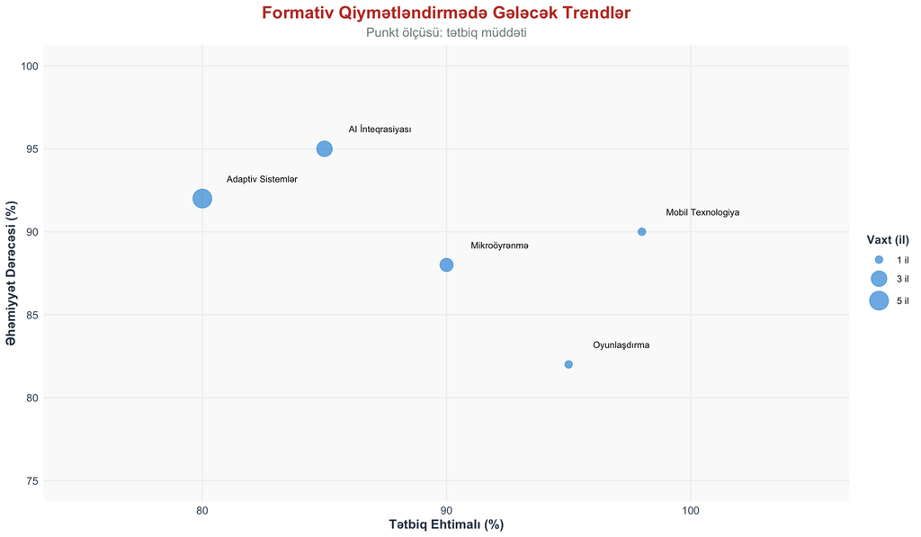

```r
# Gələcək trendlərin əhəmiyyət dərəcəsi
future_trends <- tibble(
  Trend = c("AI İnteqrasiyası", "Mikroöyrənmə", "Oyunlaşdırma",
            "Mobil Texnologiya", "Adaptiv Sistemlər"),
  Əhəmiyyət = c(95, 88, 82, 90, 92),
  Tətbiq_Ehtimalı = c(85, 90, 95, 98, 80),
  Vaxt_Çərçivəsi = c(3, 2, 1, 1, 5) # il
)

trends_plot <- future_trends %>%
  ggplot(aes(x = Tətbiq_Ehtimalı, y = Əhəmiyyət)) +
  geom_point(aes(size = Vaxt_Çərçivəsi), alpha = 0.7, color = "#3498db") +
  geom_text(aes(label = Trend), hjust = 0, vjust = 0,
            nudge_x = 1, nudge_y = 1, size = 3) +
  scale_size_continuous(range = c(3, 8), name = "Vaxt (il)",
                       breaks = c(1, 3, 5), labels = c("1 il", "3 il", "5 il")) +
  scale_x_continuous(limits = c(75, 105)) +
  scale_y_continuous(limits = c(75, 100)) +
  labs(
    title = "Formativ Qiymətləndirmədə Gələcək Trendlər",
    subtitle = "Punkt ölçüsü: tətbiq müddəti",
    x = "Tətbiq Ehtimalı (%)",
    y = "Əhəmiyyət Dərəcəsi (%)"
  ) +
  theme_formative()

print(trends_plot)
```

```r
cat("\n🔮 GƏLƏCƏK TREND TƏHLİLİ:\n")
```

```
#>
#> 🔮 GƏLƏCƏK TREND TƏHLİLİ:
```

```r
cat("========================\n")
cat("🏆 Ən əhəmiyyətli trend:", future_trends$Trend[which.max(future_trends$Əhəmiyyət)], "\n")
```

```
#> 🏆 Ən əhəmiyyətli trend: AI İnteqrasiyası
```

```r
cat("⚡ Ən tez tətbiq olunacaq:", future_trends$Trend[which.max(future_trends$Tətbiq_Ehtimalı)], "\n")
```

```
#> ⚡ Ən tez tətbiq olunacaq: Mobil Texnologiya
```

```r
cat("📅 Orta tətbiq müddəti:", round(mean(future_trends$Vaxt_Çərçivəsi), 1), "il\n")
```

```
#> 📅 Orta tətbiq müddəti: 2.4 il
```

## 8.2 Vacib Qeydlər

> **⚠️ Xatırlatma:** Formativ qiymətləndirmə davamlı proses tələb edir. Məlumatların keyfiyyəti, müntəzəm yenilənməsi və düzgün interpretasiyası sistemin uğurunda həlledici rol oynayır.

> **🎯 Məqsəd:** Formativ qiymətləndirmə sadəcə qiymətləndirmə deyil, öyrənmənin özünün təkmilləşdirilməsidir!

## 8.3 Tövsiyələr

Formativ qiymətləndirməni uğurla tətbiq etmək üçün:

1. **Davamlılıq:** Formativ qiymətləndirməni dərsin təbii hissəsi edin
2. **Müxtəliflik:** Müxtəlif texnikaları birləşdirərək tələbə ehtiyaclarını qarşılayın
3. **Şəffaflıq:** Qiymətləndirmə məqsədlərini tələbələrlə paylaşın
4. **Fleksibillik:** Nəticələrə əsasən strategiyaları dəyişməyə hazır olun
5. **Dəstək:** Tələbələrə özlərini inkişaf etdirmək üçün lazım olan alətləri verin

```r
# Dərsin ümumi statistikası
lesson_stats <- tibble(
  Göstərici = c("Əhatə olunan mövzu sayı", "Təhlil edilən texnika sayı",
                "Rəqəmsal alət sayı", "Praktik strategiya sayı"),
  Sayı = c(5, 6, 6, 15),
  Əhəmiyyət = c("Yüksək", "Yüksək", "Orta", "Yüksək")
)

kable(lesson_stats,
      caption = "Dərs 5 - Ümumi Statistika",
      col.names = c("Göstərici", "Sayı", "Əhəmiyyət Dərəcəsi")) %>%
  kable_styling(bootstrap_options = c("striped", "hover", "condensed", "responsive")) %>%
  column_spec(1, bold = TRUE, color = "white", background = "#3498db") %>%
  column_spec(3, bold = TRUE)
```

Dərs 5 - Ümumi Statistika

| Göstərici | Sayı | Əhəmiyyət Dərəcəsi |
| --- | --- | --- |
| Əhatə olunan mövzu sayı | 5 | Yüksək |
| Təhlil edilən texnika sayı | 6 | Yüksək |
| Rəqəmsal alət sayı | 6 | Orta |
| Praktik strategiya sayı | 15 | Yüksək |

```r
cat("\n📋 DƏRS 5 ÜMUMI STATİSTİKA:\n")
```

```
#>
#> 📋 DƏRS 5 ÜMUMI STATİSTİKA:
```

```r
cat("===========================\n")
cat("📚 Əhatə olunan əsas sahələr: 5\n")
```

```
#> 📚 Əhatə olunan əsas sahələr: 5
```

```r
cat("🛠️ Təqdim edilən praktik alət: 21\n")
```

```
#> 🛠️ Təqdim edilən praktik alət: 21
```

```r
cat("📊 Yaradılmış vizualizasiya: 7\n")
```

```
#> 📊 Yaradılmış vizualizasiya: 7
```

```r
cat("💻 Təhlil edilən rəqəmsal alət: 6\n")
```

```
#> 💻 Təhlil edilən rəqəmsal alət: 6
```

```r
cat("🎯 Təqdim edilən strategiya: 15\n")
```

```
#> 🎯 Təqdim edilən strategiya: 15
```

## 8.4 **DƏRS 5 TAMAMLANDI! 🎉**

**Formativ qiymətləndirmə strategiyalarını uğurla mənimsədiniz!**

**İndi dərslərinizdə tez və effektiv geribildirim verə bilərsiniz! 🚀**

### 8.4.1 Növbəti Addımlar

1. **Sistem İnteqrasiyası:** Hazırladığınız alətləri real təhsil mühitində test edin
2. **Davamlı İnkişaf:** Strategiyaların effektivliyini izləyin və təkmilləşdirin
3. **Kollaborativ Yanaşma:** Həmkarlarınızla təcrübə mübadiləsi aparın
4. **Araşdırma Fəaliyyəti:** Alınan nəticələri araşdırma və ya paylaşım məqalələrində istifadə edin

**📚 Növbəti dərs mövzuları:** - Summativ qiymətləndirmə strategiyaları - Portfolio əsaslı qiymətləndirmə - Çoxsahəli qiymətləndirmə sistemləri - Standartlaşdırılmış test hazırlama

**Uğurlar! 🌟**